# Introduction à R

4 novembre 2019

## Ressources

Quasi-infinité de ressources en lignes, parmi lesquelles :

- **Quick-R** https://www.statmethods.net/about/sitemap.html
- les cheat-sheets :
  - **R** https://rstudio.com/wp-content/uploads/2016/10/r-cheat-sheet-3.pdf
  - **dplyr** https://github.com/rstudio/cheatsheets/raw/master/data-transformation.pdf
  - **ggplot2** https://github.com/rstudio/cheatsheets/raw/master/data-visualization-2.1.pdf

Diapositives de ce cours disponibles sur

https://github.com/chapinux/introduction_a_R

## R et Rstudio

R est un outil dédié aux statistiques et à l'analyse de données, à la fois:

- un langage de programmation
- un logiciel (interpréteur, console, gestion I/O, affichage )

RStudio est l' *IDE* de R:

- Editeur
- Console R
- Environnement (objets en mémoire)
- Affichage des graphiques et Aide
- Gestion des fichiers, packages

## Points forts

- Combo R-Rstudio **gratuit**, **libre** et **multi-plateformes**
- Polyvalence et flexibilité («on peut tout faire avec R»)
- Packages spécialisés : 15192 packages officiels https://cran.r-project.org/web/views/
- Graphiques de haute qualité (`ggplot2`)
- Manipulation de données (`dplyr`, `readr`)
- Modernité : Applet shiny, RStudio Server, programmation fonctionnelle
- En évolution constante

## Points faibles

- Courbe de progression "raide"
- Éparpillement (relatif) cf. python ou javascript
- Performances ⚠ dans certains cas (e.g. boucles imbriquées)
- Mémoire : pas de gestion fine, ni streaming ⚠ de base
- 3D limitée
- Interactivité limitée (user input)

Pour les développeurs :

- Maintenabilité du code / package
- Mono-threaded , programmation parallèle non-immédiate

## Rstudio vite fait

4 panels :

1. Éditeur
2. Environnement
3. Consoles
4. affichage (graphiques et doc notamment)

## 6 raccourcis quotidiens

Complétion : touche TAB

Affichage documentation: curseur sur mot-clé puis touche F1

Commande précédente (historique console) : touche 🡑

Effacer le contenu de la console : Ctrl + L

Focus(curseur) sur Console : Ctrl + 2

Focus(curseur) sur Éditeur : Ctrl + 1

Liste complète sur: https://support.rstudio.com/hc/en-us/articles/200711853-Keyboard-Shortcuts

## Concepts du langage Doc, packages, répertoire

## Afficher la documentation dans Rstudio

Pour une fonction e.g. `mean` :

```r
?mean
# ou
help("mean")
```

Pour un terme

```r
help.search("chi square")
```

Pour un package

```r
help(package = "dplyr")
```

## Installer et charger un package

Package R : ensemble de fonctions, parfois accompagnées de données

Le chargement d'un package rend toutes ses fonctions disponibles

```r
install.packages("dplyr")
```

```r
library(dplyr) # charge le package
data("starwars") #invoque le dataset starwars
paged_table(head(starwars)) #premières lignes  du dataset
```

| name | height | mass | hair_color | skin_color | eye_color | birth_year | gender | homeworld | species | films | vehicles | starships |
| --- | --- | --- | --- | --- | --- | --- | --- | --- | --- | --- | --- | --- |
| Luke Skywalker | 172 | 77 | blond | fair | blue | 19.0 | male | Tatooine | Human |  |  |  |
| C-3PO | 167 | 75 | NA | gold | yellow | 112.0 | NA | Tatooine | Droid |  |  |  |
| R2-D2 | 96 | 32 | NA | white, blue | red | 33.0 | NA | Naboo | Droid |  |  |  |
| Darth Vader | 202 | 136 | none | white | yellow | 41.9 | male | Tatooine | Human |  |  |  |
| Leia Organa | 150 | 49 | brown | light | brown | 19.0 | female | Alderaan | Human |  |  |  |
| Owen Lars | 178 | 120 | brown, grey | light | blue | 52.0 | male | Tatooine | Human |  |  |  |

## Working directory

Connaître le repertoire de travail: fonction `getwd()`

Définir le répertoire de travail

Unix:

```r
setwd("le/path/vers/l'emplacement/")
```

Pour windows:

```r
setwd("C:\\path\\bizarrrement\\exprimé\\vers\\l'emplacement")`
```

⚠ éviter les espaces et accents dans les chemins

## Concepts du langage Données et Structures de données

## Affectation

Signe `<-` ou `=`

```r
x <-  1
x*2      # affichage sortie standard
```

```
## [1] 2
```

```r
x <- "abc"
x
```

```
## [1] "abc"
```

```r
x <-  4
x + "b"
```

```
## Error in x + "b": argument non numérique pour un opérateur binaire
```

## classes

La fonction `class` renvoie la classe des objets R

```r
w <-  12.5
class(w)
```

```
## [1] "numeric"
```

```r
x <-  TRUE
class(x)
```

```
## [1] "logical"
```

```r
y <-  "abc"
class(y)
```

```
## [1] "character"
```

## classes

```r
z1 <-  c("Leonardo", "Rapahelo", "Michelangelo", "Donatello")
class(z1)
```

```
## [1] "character"
```

```r
z2 <-  c(1,3,5,7,9)
class(z2)
```

```
## [1] "numeric"
```

```r
z3 <-  c(1,3,5,7,"pouet")
class(z3) # ?
```

Quelle est la classe de z3 ? Pourquoi ?  
On peut faire un peu de POO en R, nous ne le ferons pas.

## Aperçu des collections et tableaux

Vecteurs définis par `c()` (extension)

```r
w <-  c(1,2,3,4,5)
w + 1
```

```
## [1] 2 3 4 5 6
```

ou `vector(mode, length)` (initialisation, ~intension)

```r
v <-  vector("character", 5)
v
```

```
## [1] "" "" "" "" ""
```

Tous les éléments doivent être de même type

## Aperçu des collections et tableaux

Tableaux définis par `array(data, dim )`

```r
v <-  array("go", c(2,3))
v
```

```
##      [,1] [,2] [,3]
## [1,] "go" "go" "go"
## [2,] "go" "go" "go"
```

Matrices

```r
m <-  matrix(1, nrow = 4, ncol = 8)
m
```

```
##      [,1] [,2] [,3] [,4] [,5] [,6] [,7] [,8]
## [1,]    1    1    1    1    1    1    1    1
## [2,]    1    1    1    1    1    1    1    1
## [3,]    1    1    1    1    1    1    1    1
## [4,]    1    1    1    1    1    1    1    1
```

## Objets structurés

Objets plus complexes (~struct en C, named tuple en python)

```r
tmnt <-  list(
              nom= c("leo", "raph", "mick", "don"),
              couleur =c("bleu","rouge", "orange", "violet"),
              age=17:14
              )
tmnt
```

```
## $nom
## [1] "leo"  "raph" "mick" "don"
##
## $couleur
## [1] "bleu"   "rouge"  "orange" "violet"
##
## $age
## [1] 17 16 15 14
```

## Objets structurés imbriqués

les attributs peuvent être de longueur différentes, un attribut peut lui même être une liste :

```r
nested <- list(tmnt= tmnt,
              auteurs =c("Kevin Eastman","Peter Laird"),
              annee_parution= 1984)
nested
```

```
## $tmnt
## $tmnt$nom
## [1] "leo"  "raph" "mick" "don"
##
## $tmnt$couleur
## [1] "bleu"   "rouge"  "orange" "violet"
##
## $tmnt$age
## [1] 17 16 15 14
##
##
## $auteurs
## [1] "Kevin Eastman" "Peter Laird"
##
## $annee_parution
## [1] 1984
```

## Dataframes

Si tous les attributs d'un objet/liste ont la **même taille**, on parle de **dataframe** (~cf panda en python).

Format courant (et fortement conseillé) :

- **variables** en **colonnes**
- **individus** (observations) en **lignes**

Le dataframe est l'objet standard de R.

```
##     Sepal.Length Sepal.Width Petal.Length Petal.Width    Species
## 1            5.1         3.5          1.4         0.2     setosa
## 2            4.9         3.0          1.4         0.2     setosa
## 3            4.7         3.2          1.3         0.2     setosa
## 4            4.6         3.1          1.5         0.2     setosa
## 5            5.0         3.6          1.4         0.2     setosa
## 6            5.4         3.9          1.7         0.4     setosa
## 7            4.6         3.4          1.4         0.3     setosa
## 8            5.0         3.4          1.5         0.2     setosa
## 9            4.4         2.9          1.4         0.2     setosa
## 10           4.9         3.1          1.5         0.1     setosa
## 11           5.4         3.7          1.5         0.2     setosa
## 12           4.8         3.4          1.6         0.2     setosa
## 13           4.8         3.0          1.4         0.1     setosa
## 14           4.3         3.0          1.1         0.1     setosa
```

[output cut: 136 more lines]

## Dataframes

Les colonnes d'un dataframe sont nommées: `names(mydata)`

```r
data(iris)
names(iris)
```

```
## [1] "Sepal.Length" "Sepal.Width"  "Petal.Length" "Petal.Width"
## [5] "Species"
```

opérateur de sélection d'attributs `$` (colonne pour les dataframe) ~notation pointée en POO

```r
iris$Sepal.Length
```

```
##   [1] 5.1 4.9 4.7 4.6 5.0 5.4 4.6 5.0 4.4 4.9 5.4 4.8 4.8 4.3 5.8 5.7 5.4
##  [18] 5.1 5.7 5.1 5.4 5.1 4.6 5.1 4.8 5.0 5.0 5.2 5.2 4.7 4.8 5.4 5.2 5.5
##  [35] 4.9 5.0 5.5 4.9 4.4 5.1 5.0 4.5 4.4 5.0 5.1 4.8 5.1 4.6 5.3 5.0 7.0
##  [52] 6.4 6.9 5.5 6.5 5.7 6.3 4.9 6.6 5.2 5.0 5.9 6.0 6.1 5.6 6.7 5.6 5.8
##  [69] 6.2 5.6 5.9 6.1 6.3 6.1 6.4 6.6 6.8 6.7 6.0 5.7 5.5 5.5 5.8 6.0 5.4
##  [86] 6.0 6.7 6.3 5.6 5.5 5.5 6.1 5.8 5.0 5.6 5.7 5.7 6.2 5.1 5.7 6.3 5.8
## [103] 7.1 6.3 6.5 7.6 4.9 7.3 6.7 7.2 6.5 6.4 6.8 5.7 5.8 6.4 6.5 7.7 7.7
## [120] 6.0 6.9 5.6 7.7 6.3 6.7 7.2 6.2 6.1 6.4 7.2 7.4 7.9 6.4 6.3 6.1 7.7
## [137] 6.3 6.4 6.0 6.9 6.7 6.9 5.8 6.8 6.7 6.7 6.3 6.5 6.2 5.9
```

## Sélection dans un tableau

Pour un d'un dataframe `df`

Élément ligne `i` colonne `j` : `df[i,j]`

Toutes les lignes , colonne `j` : `df[,j]`

Toutes les colonnes , ligne `i` : `df[i,]`

Toutes les lignes sauf la ligne `i` , toutes les colonnes : `df[-i,]`

## Lire un fichier : un exemple de doc

`read.csv(file, header = TRUE, sep = ",", quote = "\"", dec = ".", fill = TRUE, comment.char = "", ...)`

- N.B. arguments avec **valeurs par défaut**
- Description : ce que fait la fonction
- Usage : comment l'écrire
- Arguments : quoi fournir à la fonction
- Details : détails (!)
- Value : valeur et type retournés
- […]

## Concepts du langage Structure de contrôle du langage

## Conditionnelles

```r
x <-  rnorm(1)
if(x>0.5){
  cat("Pile")
}else{
  cat("Face")
}
```

```
## Face
```

Au passage :

- `rnorm()` échantillone selon une loi normale
- `cat()` affiche sur la sortie standard / concatène (~print)

## Conditionnelles

| opérateur | syntaxe |
| --- | --- |
| AND | `x && y` |
| OR | `x \\|\\| y` |
| XOR | `xor(x,y)` |
| NOT | `!x` |
| missing ? | `is.na(x)` |
| null ? | `is.null(x)` |

+ opérateurs binaires classiques: `>, < , >= , <=, == , != , %in%`

## Boucles

```r
for(i in 1:10){
  xx <-  i * 2
  cat(xx, " ")
  }
```

```
## 2  4  6  8  10  12  14  16  18  20
```

⚠ Au-delà de deux boucles imbriquées, les performances de R s'effondrent

## Boucles

Toute séquence peut être utilisée pour l'itération :

```r
for(i in LETTERS){
  print(i)
  }
```

```
## [1] "A"
## [1] "B"
## [1] "C"
## [1] "D"
## [1] "E"
## [1] "F"
## [1] "G"
## [1] "H"
## [1] "I"
## [1] "J"
## [1] "K"
## [1] "L"
## [1] "M"
## [1] "N"
## [1] "O"
## [1] "P"
## [1] "Q"
## [1] "R"
## [1] "S"
## [1] "T"
## [1] "U"
## [1] "V"
## [1] "W"
## [1] "X"
## [1] "Y"
## [1] "Z"
```

## Boucles

```r
i <- 0
while(i < 15){
  i <- i+1
  cat(i,"")
  }
```

```
## 1 2 3 4 5 6 7 8 9 10 11 12 13 14 15
```

## Boucles

Fonction pratiques pour générer des séquences : `seq` et `rep`

```r
seq(from=24, by= 0.33, length.out = 17)
```

```
##  [1] 24.00 24.33 24.66 24.99 25.32 25.65 25.98 26.31 26.64 26.97 27.30
## [12] 27.63 27.96 28.29 28.62 28.95 29.28
```

```r
rep(c("lundi", "mardi", "mercredi", "jeudi"), 4)
```

```
##  [1] "lundi"    "mardi"    "mercredi" "jeudi"    "lundi"    "mardi"
##  [7] "mercredi" "jeudi"    "lundi"    "mardi"    "mercredi" "jeudi"
## [13] "lundi"    "mardi"    "mercredi" "jeudi"
```

```r
cat(c((rep("po-", 4)),"ker face"), sep="")
```

```
## po-po-po-po-ker face
```

[figure not shown]

## Fonction

```r
nom_de_la_fonction <- function(arg1, arg2, ...){
    ⋮
  code de la fonction
    ⋮
    ⋮
    ⋮
  return(resultat)
}
```

## les librairies du futur dplyr, sf, cartography et ggplot2

## dplyr

Transformation, combinaison, requêtage de données

e.g. : `group_by, filter, intersects, union, join, n_distinct`

https://rstudio.com/wp-content/uploads/2015/02/data-wrangling-cheatsheet.pdf

## sf

package de manipulation de données spatiales (vecteur), implémente la norme sf (Simple Feature) , comme postgis.

La géométrie des objets "voyage" avec eux à chaque opération.

## ggplot2

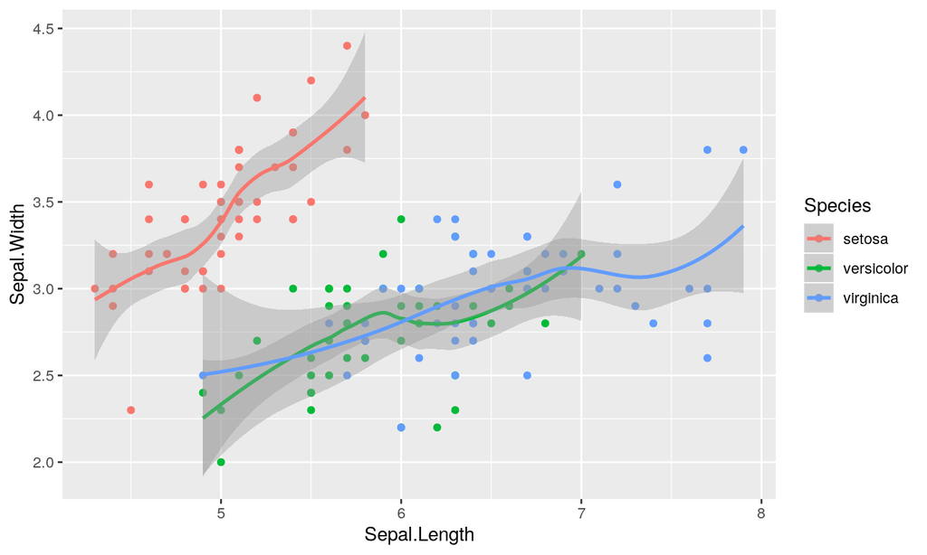

```r
library(ggplot2)
ggplot(iris, aes(Sepal.Length, Sepal.Width, colour = Species)) +
  geom_point()+
  geom_smooth()
```

https://github.com/rstudio/cheatsheets/raw/master/data-visualization-2.1.pdf

## cartography

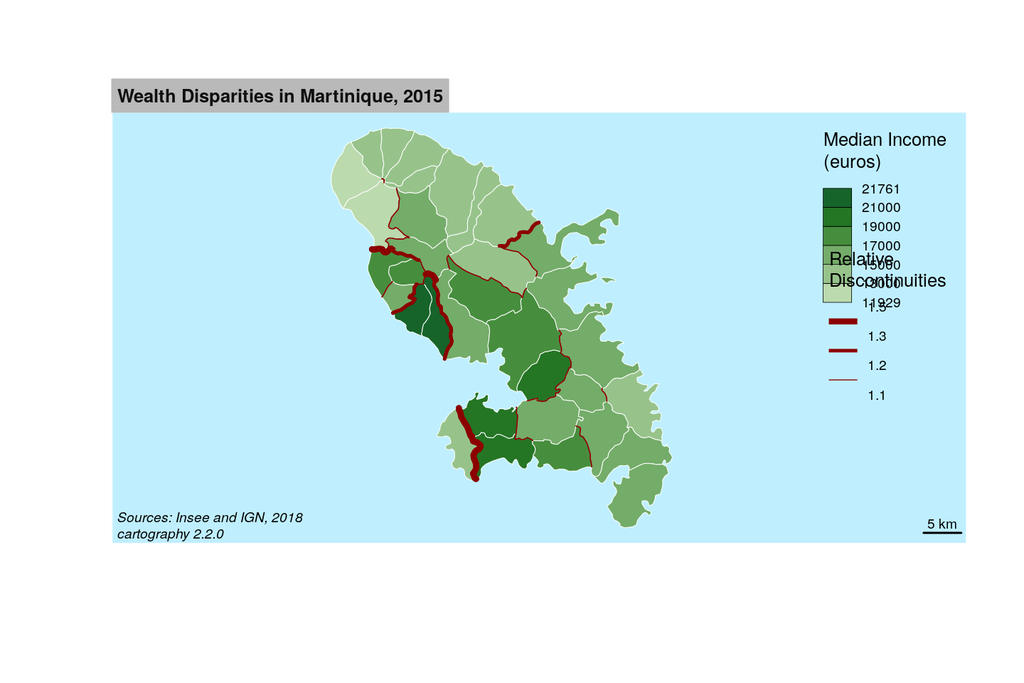

https://cran.r-project.org/web/packages/cartography/vignettes/cartography.html

https://rgeomatic.hypotheses.org/category/cartography